# Exploración de Datos con R

El objetivo de este trabajo es explicar de forma detallada como se explora de manera visual un set de datos con la herramienta R.

Se utilizó como referencia el MOOC  
[Exploring Data Analysis Using R.](https://www.mooc-list.com/course/data-analysis-r-udacity)

Cargamos las librerias

```r
#install.packages('GGally')
#install.packages('scales')
#install.packages('memisc')
#install.packages('car')
#install.packages('lattice')
#install.packages('MASS')
#install.packages('reshape2')
#install.packages('ggplot2')
#install.packages('plyr')
#install.packages('grid')
#install.packages('gridExtra')
#install.packages('digest')

library(GGally)
library(scales)
library(memisc)
library(car)
library(lattice)
library(MASS)
library(reshape2)
library(ggplot2)
library(plyr)
library(grid)
library(gridExtra)
library(digest)
```

Exploramos las primeras lineas del Dataset

```r
head(diamonds)
```

```
##   carat       cut color clarity depth table price    x    y    z
## 1  0.23     Ideal     E     SI2  61.5    55   326 3.95 3.98 2.43
## 2  0.21   Premium     E     SI1  59.8    61   326 3.89 3.84 2.31
## 3  0.23      Good     E     VS1  56.9    65   327 4.05 4.07 2.31
## 4  0.29   Premium     I     VS2  62.4    58   334 4.20 4.23 2.63
## 5  0.31      Good     J     SI2  63.3    58   335 4.34 4.35 2.75
## 6  0.24 Very Good     J    VVS2  62.8    57   336 3.94 3.96 2.48
```

Inspeccionamos la estructura del Dataset

```r
summary(diamonds)
```

```
##      carat               cut        color        clarity
##  Min.   :0.2000   Fair     : 1610   D: 6775   SI1    :13065
##  1st Qu.:0.4000   Good     : 4906   E: 9797   VS2    :12258
##  Median :0.7000   Very Good:12082   F: 9542   SI2    : 9194
##  Mean   :0.7979   Premium  :13791   G:11292   VS1    : 8171
##  3rd Qu.:1.0400   Ideal    :21551   H: 8304   VVS2   : 5066
##  Max.   :5.0100                     I: 5422   VVS1   : 3655
##                                     J: 2808   (Other): 2531
##      depth           table           price             x
##  Min.   :43.00   Min.   :43.00   Min.   :  326   Min.   : 0.000
##  1st Qu.:61.00   1st Qu.:56.00   1st Qu.:  950   1st Qu.: 4.710
##  Median :61.80   Median :57.00   Median : 2401   Median : 5.700
##  Mean   :61.75   Mean   :57.46   Mean   : 3933   Mean   : 5.731
##  3rd Qu.:62.50   3rd Qu.:59.00   3rd Qu.: 5324   3rd Qu.: 6.540
##  Max.   :79.00   Max.   :95.00   Max.   :18823   Max.   :10.740
##
##        y                z
##  Min.   : 0.000   Min.   : 0.000
##  1st Qu.: 4.720   1st Qu.: 2.910
##  Median : 5.710   Median : 3.530
##  Mean   : 5.735   Mean   : 3.539
##  3rd Qu.: 6.540   3rd Qu.: 4.040
##  Max.   :58.900   Max.   :31.800
##
```

```r
str(diamonds)
```

```
## 'data.frame':    53940 obs. of  10 variables:
##  $ carat  : num  0.23 0.21 0.23 0.29 0.31 0.24 0.24 0.26 0.22 0.23 ...
##  $ cut    : Ord.factor w/ 5 levels "Fair"<"Good"<..: 5 4 2 4 2 3 3 3 1 3 ...
##  $ color  : Ord.factor w/ 7 levels "D"<"E"<"F"<"G"<..: 2 2 2 6 7 7 6 5 2 5 ...
##  $ clarity: Ord.factor w/ 8 levels "I1"<"SI2"<"SI1"<..: 2 3 5 4 2 6 7 3 4 5 ...
##  $ depth  : num  61.5 59.8 56.9 62.4 63.3 62.8 62.3 61.9 65.1 59.4 ...
##  $ table  : num  55 61 65 58 58 57 57 55 61 61 ...
##  $ price  : int  326 326 327 334 335 336 336 337 337 338 ...
##  $ x      : num  3.95 3.89 4.05 4.2 4.34 3.94 3.95 4.07 3.87 4 ...
##  $ y      : num  3.98 3.84 4.07 4.23 4.35 3.96 3.98 4.11 3.78 4.05 ...
##  $ z      : num  2.43 2.31 2.31 2.63 2.75 2.48 2.47 2.53 2.49 2.39 ...
```

Descripción  
Conjunto de datos que contiene los precios y otros atributos de casi 54.000 diamantes.

Formato  
53.940 filas y 10 variables.

Tomamos una muestra aleatoria y graficamos las matrices de nube de puntos entre las variables

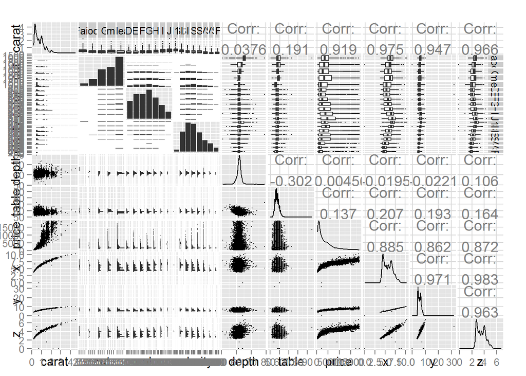

```r
set.seed(20022012)
diamond_samp<-diamonds[sample(1:length(diamonds$price),10000),]
ggpairs(diamond_samp, params = c(shape = I('.'), outlier.shape = I('.')))
```

**ggpairs** grafica la interacción entre cada una de las variables. En la diagonal principial aparece cada variable contra sí misma. El triángulo inferior utiliza histogramas agrupados para parejas de datos cualitativos y diagramas de dispersión para parejas de datos cuantitativos. El triángulo superior utiliza histogramas agrupados para parejas de datos cualitativos (con el x en lugar y como factor de agrupamiento ), diagramas de caja para los pares cualitativos cuantitativos, y proporciona la correlación de pares cuantitativos - cuantitativos.

Lo que realmente importa aquí es el precio, asi que vamos a centrarnos en eso. Podemos estudiar la relación entre precio y claridad o precio y color(de hecho lo vamos a ver más adelante) pero el factor crítico que determina el precio es el tamaño del diamante .

Sin embargo, como vimos anteriormente en la Matriz de Scatterplot, la relación entre el precio y el tamaño del diamante no es lineal. Â¿Qué podría explicar este patrón?

Por el lado de la oferta, es mucho más difícil encontrar grandes trozos que pequeños sin defectos. Esta razón podría ayudar a explicar la forma exponencial que tiene la curva precio-peso.Por supuesto, esto está relacionado con el hecho de que el peso de un diamante es una función del volumen y el volumen es una función de x * y * z, lo que sugiere que podría ser interesante estudiar la raíz cúbica del peso en quilates.

Por el lado de la demanda, los clientes menos adinerados son más sensibles a los precios. Por lo tanto, no debemos esperar que el mercado de los diamantes más grandes sea tan competitivo como el de los más pequeños, así que tiene sentido que la varianza, así como el precio aumentaría con el tamaño de quilates.

A menudo, las variables monetarias se distribuyen segun una lognormal.  
Por lo tanto, es una buena idea mirar la variable price en una escala logarítmica.

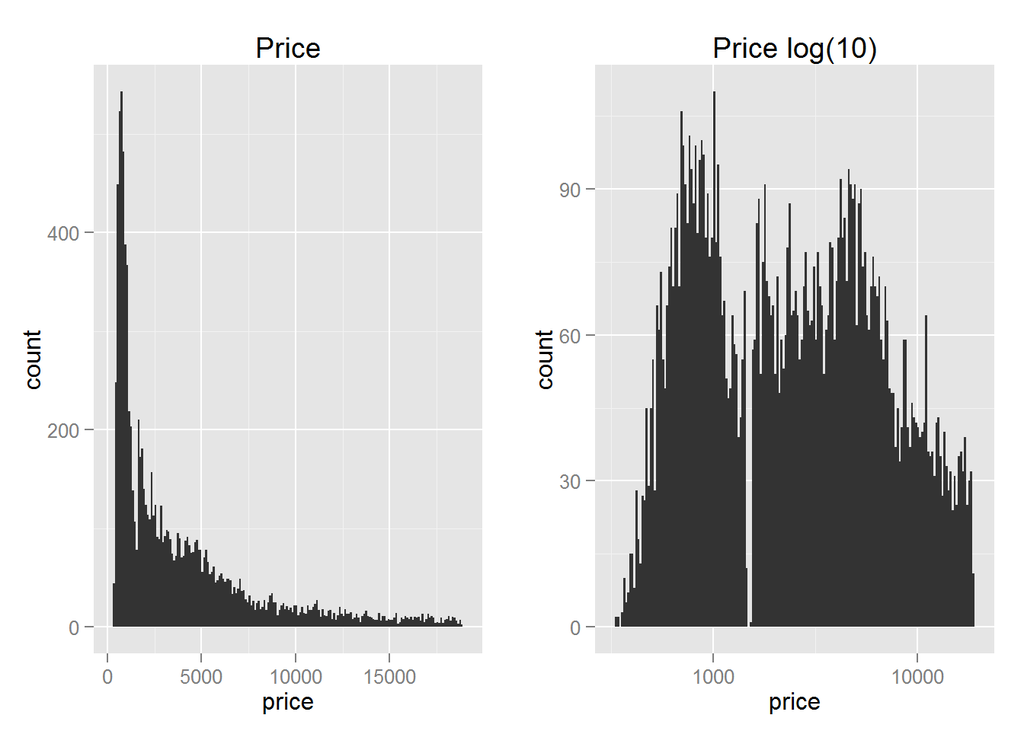

```r
plot1<-qplot(x=price, data = diamond_samp, binwidth=100)+
  ggtitle('Price')
plot2<-qplot(x=price, data = diamond_samp, binwidth=0.01)+
  ggtitle('Price log(10)')+
  scale_x_log10()
grid.arrange(plot1, plot2, ncol=2)
```

Podemos ver que los precios de los diamantes estan sesgados. Pero cuando se ponen en una escala log10 parecen comportarse como una curva Normal. De hecho, los datos muestran cierta evidencia de bimodalidad en la escala log10 en consonancia con las dos clases de compradores propias de la naturaleza del mercado de diamantes, “rico-comprador” y “pobre-comprador”.

Volvemos a graficar pero ahora ponemos al precio en escala logarítmica

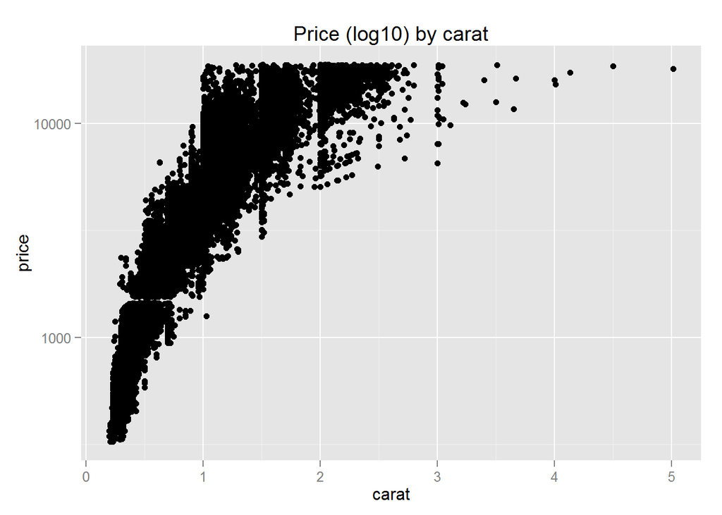

```r
qplot(x=carat, y=price, data = diamonds)+
  scale_y_continuous(trans = log10_trans())+
  ggtitle('Price (log10) by carat')
```

Como el volumen está en una escala cúbica reformamos la cuestión

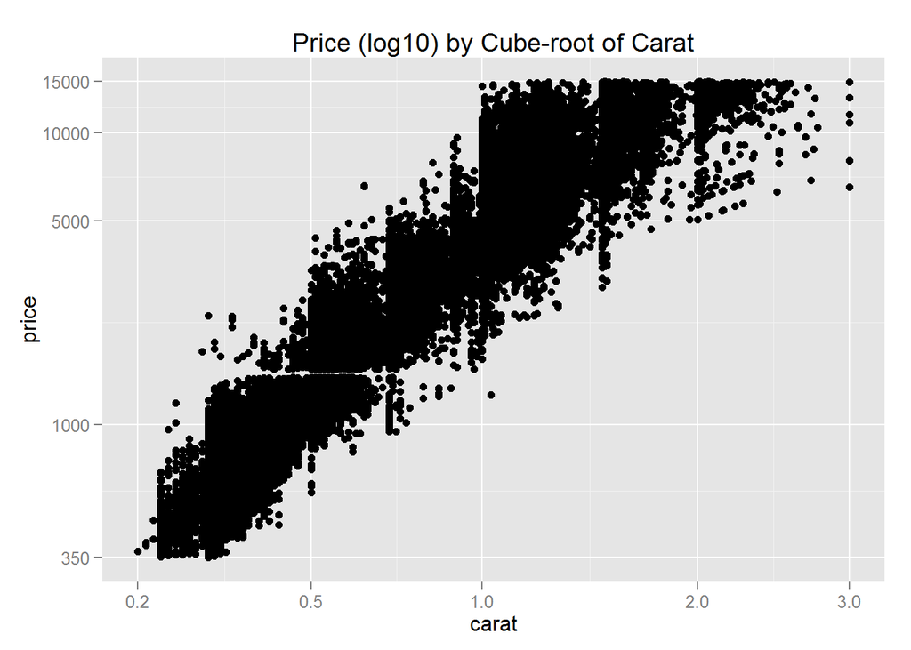

```r
cuberoot_trans = function() trans_new('cuberoot',
                                      transform = function(x) x^(1/3),
                                      inverse = function(x) x^3)


ggplot(aes(carat, price), data = diamonds)+
  geom_point()+
  scale_x_continuous(trans=cuberoot_trans(), limits = c(0.2,3),
                     breaks = c(0.2, 0.5, 1, 2, 3))+
  scale_y_continuous(trans = log10_trans(), limits =c(350,15000),
                     breaks=c(350,1000,5000,10000,15000))+
  ggtitle('Price (log10) by Cube-root of Carat')
```

Luego de aplicar las transformaciones la relación entre ambas variables parece casi lineal.

## Overplotting

Con tantos puntos se hace difícil saber cuántos hay en cada región. Así que podemos establecer la transparencia de los puntos utilizando el parámetro alfa. El parámetro alfa igual a 1 sobre 20 significa que tienen que haber 20 puntos para ser el equivalente de uno de estos puntos negros.

```r
head(sort(table(diamonds$carat), decreasing=T))
```

```
##
##  0.3 0.31 1.01  0.7 0.32    1
## 2604 2249 2242 1981 1840 1558
```

```r
head(sort(table(diamonds$price), decreasing=T))
```

```
##
## 605 802 625 828 776 698
## 132 127 126 125 124 121
```

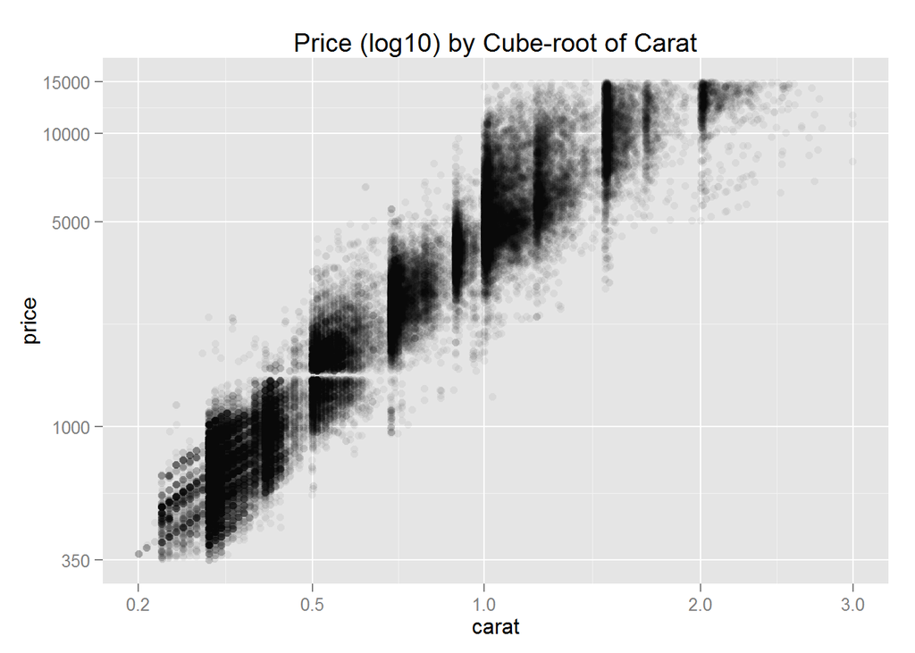

```r
ggplot(aes(carat, price), data = diamonds)+
  geom_point(alpha=1/20, position = position_jitter(h=0))+
  scale_x_continuous(trans=cuberoot_trans(), limits = c(0.2,3),
                     breaks = c(0.2, 0.5, 1, 2, 3))+
  scale_y_continuous(trans = log10_trans(), limits =c(350,15000),
                     breaks=c(350,1000,5000,10000,15000))+
  ggtitle('Price (log10) by Cube-root of Carat')
```

Esto nos da una mejor idea de cuan denso son nuestros datos en cada una de las regiones.

## El uso de colores para comprender los factores cualitativos

### Precio vs peso y claridad

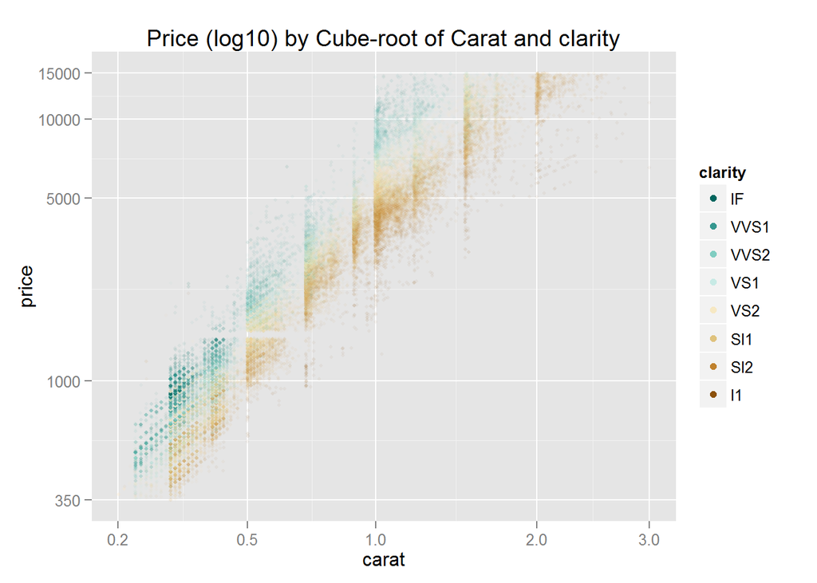

```r
ggplot(aes(x=carat, y=price, colour=clarity), data = diamonds)+
  geom_point(alpha=1/20, size= 1, position = 'jitter')+
  scale_color_brewer(type='div',
                     guide=guide_legend(tittle='clarity', reverse=TRUE,
                                        override.aes = list(alpha = 1,size=2)))+
  scale_x_continuous(trans=cuberoot_trans(), limits = c(0.2,3),
                     breaks = c(0.2, 0.5, 1, 2, 3))+
  scale_y_continuous(trans = log10_trans(), limits =c(350,15000),
                     breaks=c(350,1000,5000,10000,15000))+
  ggtitle('Price (log10) by Cube-root of Carat and clarity')
```

### Precio vs peso y tipo de corte

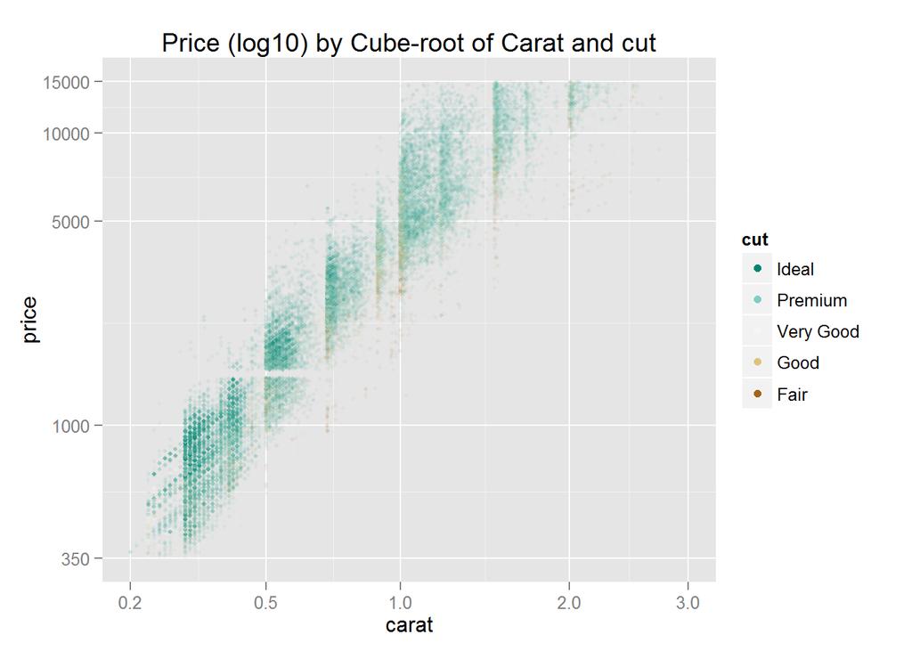

```r
ggplot(aes(x=carat, y=price, colour=cut), data = diamonds)+
  geom_point(alpha=1/20, size= 1, position = 'jitter')+
  scale_color_brewer(type='div',
                     guide=guide_legend(tittle='cut', reverse=TRUE,
                                        override.aes = list(alpha = 1,size=2)))+
  scale_x_continuous(trans=cuberoot_trans(), limits = c(0.2,3),
                     breaks = c(0.2, 0.5, 1, 2, 3))+
  scale_y_continuous(trans = log10_trans(), limits =c(350,15000),
                     breaks=c(350,1000,5000,10000,15000))+
  ggtitle('Price (log10) by Cube-root of Carat and cut')
```

### Precio vs peso y color

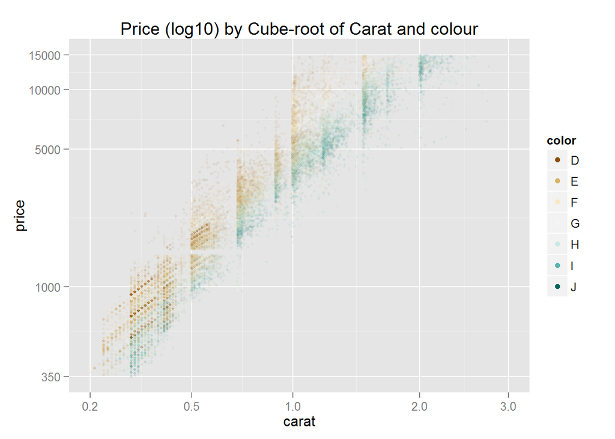

```r
ggplot(aes(x=carat, y=price, colour=color), data = diamonds)+
  geom_point(alpha=1/20, size= 1, position = 'jitter')+
  scale_color_brewer(type='div',
                     guide=guide_legend(tittle='colour', reverse=FALSE,
                                        override.aes = list(alpha = 1,size=2)))+
  scale_x_continuous(trans=cuberoot_trans(), limits = c(0.2,3),
                     breaks = c(0.2, 0.5, 1, 2, 3))+
  scale_y_continuous(trans = log10_trans(), limits =c(350,15000),
                     breaks=c(350,1000,5000,10000,15000))+
  ggtitle('Price (log10) by Cube-root of Carat and colour')
```

#### A partir de los gríficos observamos que tanto la claridad como el color son factores influyente en el Precio